# ZA Renewable Profile Validation

This notebook checks the South Africa 2023 atlite cutout and renewable profile artifacts produced for Calibration Plan module 03.

```python
from pathlib import Path

import matplotlib.pyplot as plt
import pandas as pd
import xarray as xr
from IPython.display import display

ROOT = next(p for p in (Path.cwd(), *Path.cwd().parents) if (p / "data/za_audit").exists())
VALIDATION = ROOT / "data/za_audit/za_atlite_renewable_profile_validation.csv"
TECHNICAL = ROOT / "data/za_audit/za_atlite_technical_potential.csv"
PROFILE_DIR = ROOT / "resources/za_2023_fixed_validation/renewable_profiles"

plt.rcParams.update({"figure.figsize": (10, 4), "axes.grid": True})

validation = pd.read_csv(VALIDATION)
technical = pd.read_csv(TECHNICAL)
status_counts = validation["status"].value_counts().rename_axis("status").reset_index(name="checks")
display(status_counts)
```

|  | status | checks |
| --- | --- | --- |
| 0 | pass | 29 |
| 1 | warn | 4 |

## Gate A Checks

The validation table records cutout coverage, carrier profile bounds, technical potential diagnostics, and the GEGIS `2023_custom` preflight.

```python
display(validation)

issues = validation.loc[validation["status"].isin(["warn", "fail"])].copy()
display(issues if not issues.empty else pd.DataFrame({"message": ["No warnings or failures"]}))
```

|  | carrier | check | status | value | unit | notes |
| --- | --- | --- | --- | --- | --- | --- |
| 0 | cutout | sha256 | pass | 0c6b22fa6b8a0a469cc24460df2014fdb9c041035985df... | sha256 | matches module 01 recorded hash |
| 1 | cutout | time_coverage | pass | 8760 | hours | first=2023-01-01T00:00:00.000000; last=2023-12... |
| 2 | cutout | module | pass | era5 | NaN | atlite cutout module attribute |
| 3 | cutout | resolution | pass | dx=0.3;dy=0.3 | degrees | expected ZA module 03 resolution is 0.3 x 0.3 |
| 4 | cutout | bounds | pass | Frozen({'x': 81, 'y': 58, 'time': 8760}) | NaN | x=[12.900, 36.900], y=[-38.700, -21.600] |
| 5 | solar | file | pass | ae900f83a9358fa5ee10f74612da7c2806d14463765571... | sha256 | resources/za_2023_fixed_validation/renewable_p... |
| 6 | solar | time_coverage | pass | 8760 | hours | first=2023-01-01T00:00:00.000000; last=2023-12... |
| 7 | solar | bus_count | pass | 1291 | bus | non-empty profile index |
| 8 | solar | p_nom_max | pass | 4707684.669302812 | MW | sum of nonnegative p_nom_max |
| 9 | solar | finite_values | pass | NaN | NaN | all finite |
| 10 | solar | value_bounds | pass | min=0.0;max=0.7697281998137703 | p.u. | hydro is inflow; other carriers are availabili... |
| 11 | solar | annual_availability_vs_eskom | pass | 1431.6569432978588 | ratio | availability_twh=7179.537453358979; observed_t... |
| 12 | onwind | file | pass | 2a1ae2591ad757e71eb08e8315644787fb95814c57add3... | sha256 | resources/za_2023_fixed_validation/renewable_p... |
| 13 | onwind | time_coverage | pass | 8760 | hours | first=2023-01-01T00:00:00.000000; last=2023-12... |
| 14 | onwind | bus_count | pass | 1291 | bus | non-empty profile index |
| 15 | onwind | p_nom_max | pass | 3094323.9825447546 | MW | sum of nonnegative p_nom_max |
| 16 | onwind | finite_values | pass | NaN | NaN | all finite |
| 17 | onwind | value_bounds | pass | min=0.0;max=1.0000000000000004 | p.u. | hydro is inflow; other carriers are availabili... |
| 18 | onwind | annual_availability_vs_eskom | pass | 468.13557414104207 | ratio | availability_twh=5436.62878780247; observed_tw... |
| 19 | hydro | file | pass | 25cf8e94bddf03c67302ebe049ed45c2b540814f7c1c70... | sha256 | resources/za_2023_fixed_validation/renewable_p... |
| 20 | hydro | time_coverage | warn | 1 | hours | first=None; last=None; time dimension has no c... |
| 21 | hydro | plant_count | warn | 0 | plant | upstream hydro profile is empty because build_... |
| 22 | hydro | finite_values | warn | NaN | NaN | upstream hydro profile is empty because build_... |
| 23 | hydro | value_bounds | pass | min=0.0;max=0.0 | MW | hydro is inflow; other carriers are availabili... |
| 24 | hydro | annual_availability_vs_eskom | warn | 0.0 | ratio | availability_twh=0.0; observed_twh=1.991804788... |
| 25 | csp | file | pass | 2051d6c6720542eb004374cdfa09a18b7187f1dabf23d9... | sha256 | resources/za_2023_fixed_validation/renewable_p... |
| 26 | csp | time_coverage | pass | 8760 | hours | first=2023-01-01T00:00:00.000000; last=2023-12... |
| 27 | csp | bus_count | pass | 1291 | bus | non-empty profile index |
| 28 | csp | p_nom_max | pass | 2422458.215092333 | MW | sum of nonnegative p_nom_max |
| 29 | csp | finite_values | pass | NaN | NaN | all finite |
| 30 | csp | value_bounds | pass | min=0.0;max=0.6713971620513928 | p.u. | hydro is inflow; other carriers are availabili... |
| 31 | csp | annual_availability_vs_eskom | pass | 2510.1021260644707 | ratio | availability_twh=3452.26570097021; observed_tw... |
| 32 | demand_preflight | gegis_2023_custom | pass | data/ssp2-2.6/2030/era5_2023_custom/Africa.csv | NaN | accepted 2023_custom string |

|  | carrier | check | status | value | unit | notes |
| --- | --- | --- | --- | --- | --- | --- |
| 20 | hydro | time_coverage | warn | 1 | hours | first=None; last=None; time dimension has no c... |
| 21 | hydro | plant_count | warn | 0 | plant | upstream hydro profile is empty because build_... |
| 22 | hydro | finite_values | warn | NaN | NaN | upstream hydro profile is empty because build_... |
| 24 | hydro | annual_availability_vs_eskom | warn | 0.0 | ratio | availability_twh=0.0; observed_twh=1.991804788... |

## Technical Potential

The values below are diagnostics only. No correction factors or profile scaling are applied in module 03.

|  | carrier | hours | p_nom_max_mw | technical_potential_twh | full_load_hours | area_km2 | installable_power_density_mw_per_km2 | sanity_status |
| --- | --- | --- | --- | --- | --- | --- | --- | --- |
| 0 | solar | 8760 | 4.707685e+06 | 7179.537453 | 1525.067620 | 1.023410e+06 | 4.600 | pass |
| 1 | onwind | 8760 | 3.094324e+06 | 5436.628788 | 1756.968184 | 1.031441e+06 | 3.000 | pass |
| 2 | hydro | 1 | NaN | 0.000000 | NaN | NaN | NaN | warn |
| 3 | csp | 8760 | 2.422458e+06 | 3452.265701 | 1425.108462 | 1.012733e+06 | 2.392 | pass |

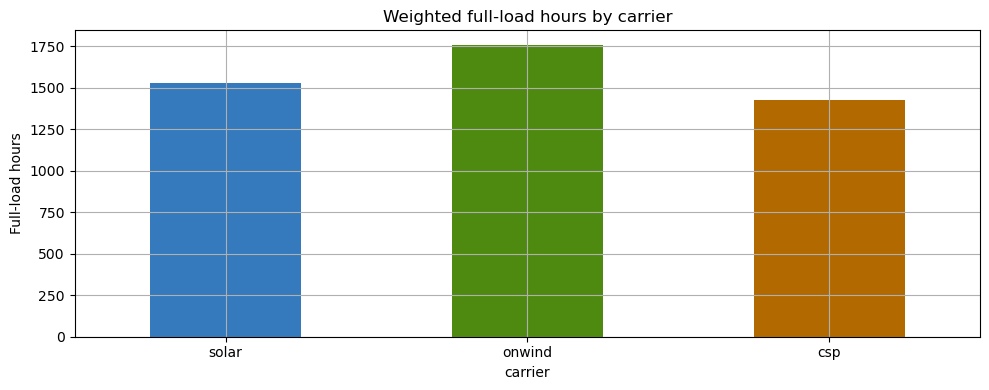

```python
cols = [
    "carrier",
    "hours",
    "p_nom_max_mw",
    "technical_potential_twh",
    "full_load_hours",
    "area_km2",
    "installable_power_density_mw_per_km2",
    "sanity_status",
]
display(technical[cols])

ax = technical.set_index("carrier")["full_load_hours"].dropna().plot(kind="bar", color=["#357ABD", "#4F8A10", "#B26A00"])
ax.set_ylabel("Full-load hours")
ax.set_title("Weighted full-load hours by carrier")
plt.xticks(rotation=0)
plt.tight_layout()
plt.show()
```

## Daily Availability Shapes

Solar, onwind, and CSP profiles are aggregated to p_nom-weighted daily availability. Hydro is omitted here because the upstream profile is empty until module 08 supplies reconciled ZA hydro plants.

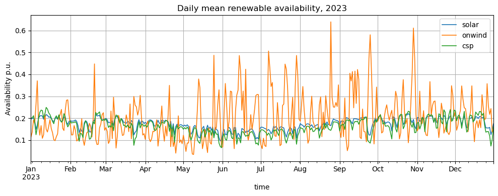

|  | count | mean | std | min | 25% | 50% | 75% | max |
| --- | --- | --- | --- | --- | --- | --- | --- | --- |
| solar | 365.0 | 0.174094 | 0.026822 | 0.095182 | 0.157455 | 0.179200 | 0.195266 | 0.220513 |
| onwind | 365.0 | 0.200567 | 0.103077 | 0.034406 | 0.124855 | 0.177478 | 0.251136 | 0.639674 |
| csp | 365.0 | 0.162684 | 0.038136 | 0.065104 | 0.137773 | 0.161612 | 0.189403 | 0.249231 |

```python
def weighted_profile(path: Path) -> pd.Series:
    ds = xr.open_dataset(path)
    weights = ds["p_nom_max"].where(ds["p_nom_max"] > 0, 0)
    profile = ds["profile"].weighted(weights).mean("bus").to_series()
    ds.close()
    profile.index = pd.to_datetime(profile.index)
    return profile

series = {
    carrier: weighted_profile(PROFILE_DIR / f"profile_{carrier}.nc").resample("D").mean()
    for carrier in ["solar", "onwind", "csp"]
}
daily = pd.DataFrame(series)
ax = daily.plot(linewidth=1.2)
ax.set_ylabel("Availability p.u.")
ax.set_title("Daily mean renewable availability, 2023")
plt.tight_layout()
plt.show()

display(daily.describe().T)
```

## CSP Carrier Check

CSP is validated as its own `csp` carrier from `profile_csp.nc`; it is not combined with PV.

```python
csp_rows = validation.loc[validation["carrier"].eq("csp") | validation["notes"].str.contains("csp|CSP", case=False, na=False)]
display(csp_rows)
```

|  | carrier | check | status | value | unit | notes |
| --- | --- | --- | --- | --- | --- | --- |
| 25 | csp | file | pass | 2051d6c6720542eb004374cdfa09a18b7187f1dabf23d9... | sha256 | resources/za_2023_fixed_validation/renewable_p... |
| 26 | csp | time_coverage | pass | 8760 | hours | first=2023-01-01T00:00:00.000000; last=2023-12... |
| 27 | csp | bus_count | pass | 1291 | bus | non-empty profile index |
| 28 | csp | p_nom_max | pass | 2422458.215092333 | MW | sum of nonnegative p_nom_max |
| 29 | csp | finite_values | pass | NaN | NaN | all finite |
| 30 | csp | value_bounds | pass | min=0.0;max=0.6713971620513928 | p.u. | hydro is inflow; other carriers are availabili... |
| 31 | csp | annual_availability_vs_eskom | pass | 2510.1021260644707 | ratio | availability_twh=3452.26570097021; observed_tw... |

## Conclusion

Module 03 Gate A passes for the verified ERA5 cutout and native solar, onwind, and CSP profiles. Hydro is present as an upstream output file but empty because the current pre-module-08 powerplant data has no known ZA hydro plants; the warning is carried forward without scaling or fallback.